# pre_run

Ziqi Zhou

3/12/2020

# Introduction

The red wine is one of the most popular alcoholic beverages in the world. Most of our team members enjoy drinking red wine and have a great interest in factors that can affect the quality of the red wine. We want to figure out what determined the quality of the wine. Based on this motivation, we choose this dataset “Red Wine Quality”.

This dataset has 12 columns and 1599 rows. And after omitting the NA data, we still got 1599 rows which means there is no missing value in this dataset.

We would like to know what factors influence the quality of the wine and try to build a model to predict the quality of wine given the specific factors.

I used the code below to prepare and clean the data.

```r
# Separate data into training data and test data
set.seed(11)
trRows = createDataPartition(wine$quality, p = .75, list = F)

#all data
x = model.matrix(quality ~ .,wine)[,-1]
y = wine$quality

# Training data
x1 = model.matrix(quality ~ .,wine)[trRows,-1]
y1 = wine$quality[trRows]

# test data
x2 = model.matrix(quality ~ .,wine)[-trRows,-1]
y2 = wine$quality[-trRows]
```

```r
#set ctrl1
ctrl1 <- trainControl(method = "cv", number = 10)
```

# Exploratory Data Analysis

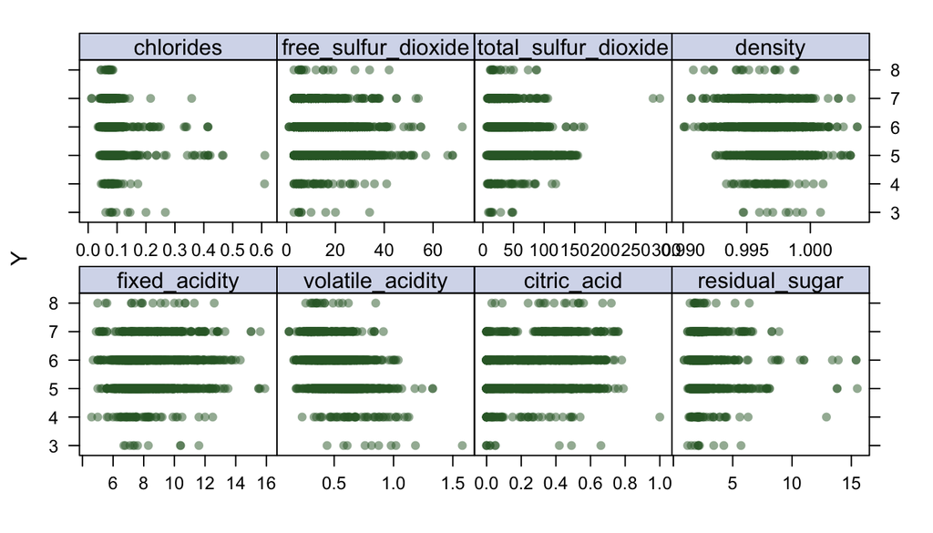

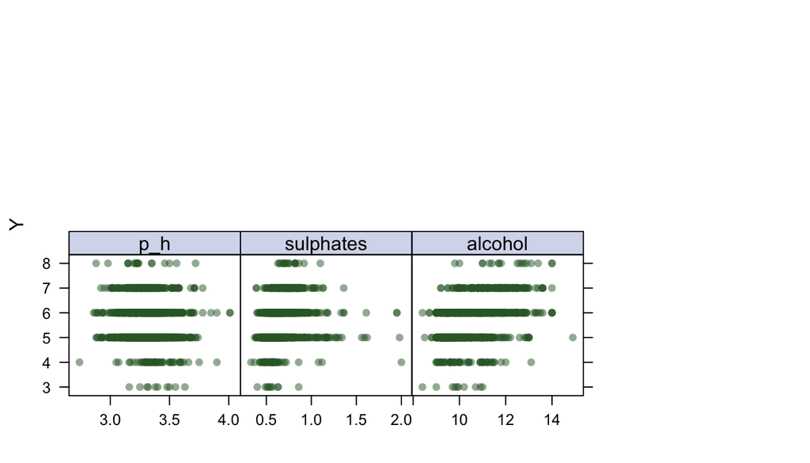

```r
#Create scatter plots of responses and predictors
theme1 <- trellis.par.get()
theme1$plot.symbol$col <- rgb(.2, .4, .2, .5)
theme1$plot.symbol$pch <- 16
theme1$plot.line$col <- rgb(.8, .1, .1, 1)
theme1$plot.line$lwd <- 2
theme1$strip.background$col <- rgb(.0, .2, .6, .2)
trellis.par.set(theme1)
featurePlot(x, y, plot = "scatter", labels = c("","Y"),
            type = c("p"), layout = c(4, 2))
```

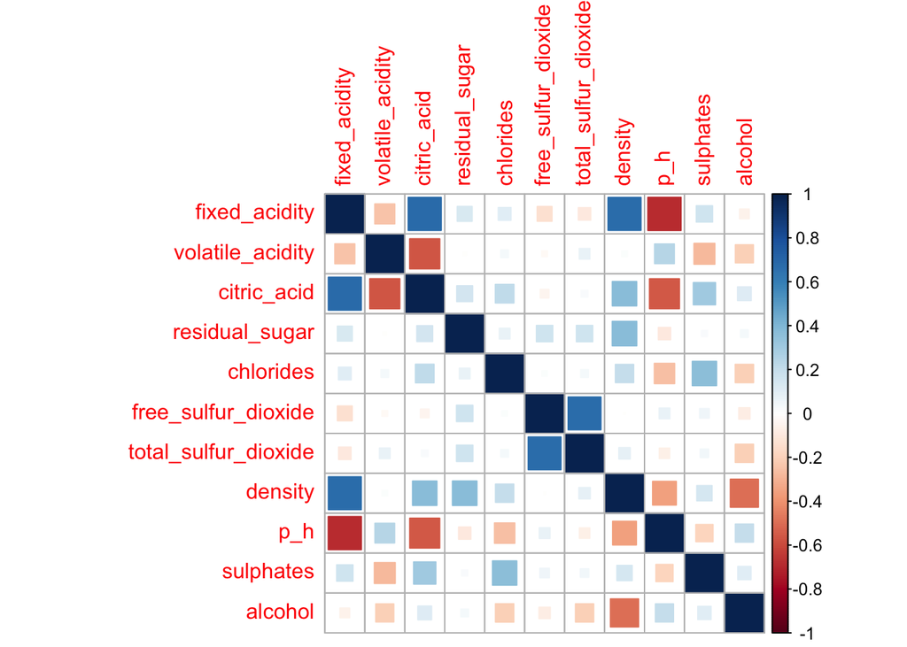

```r
corrplot(cor(x1), method = "square", type = "full")
```

**description**

pH and fixed acidity alcohol and density citric acid and fixed acidity citric acid and volatile acidity

# Models

```r
#linear fit R^2 = 0.3458
set.seed(1)
lm.fit <-train(x1, y1,method = "lm",
               trControl = ctrl1)
summary(lm.fit)
```

```
##
## Call:
## lm(formula = .outcome ~ ., data = dat)
##
## Residuals:
##      Min       1Q   Median       3Q      Max
## -2.63366 -0.38173 -0.05442  0.45126  2.09579
##
## Coefficients:
##                        Estimate Std. Error t value Pr(>|t|)
## (Intercept)          -1.836e+01  2.536e+01  -0.724  0.46936
## fixed_acidity        -2.658e-02  3.134e-02  -0.848  0.39665
## volatile_acidity     -1.163e+00  1.453e-01  -8.004 2.85e-15 ***
## citric_acid          -2.286e-01  1.780e-01  -1.284  0.19928
## residual_sugar       -4.174e-03  1.714e-02  -0.244  0.80762
## chlorides            -2.232e+00  4.894e-01  -4.561 5.62e-06 ***
## free_sulfur_dioxide   5.725e-03  2.593e-03   2.208  0.02743 *
## total_sulfur_dioxide -4.096e-03  8.567e-04  -4.781 1.96e-06 ***
## density               2.373e+01  2.590e+01   0.917  0.35958
## p_h                  -6.572e-01  2.284e-01  -2.877  0.00409 **
## sulphates             9.009e-01  1.371e-01   6.570 7.52e-11 ***
## alcohol               2.988e-01  3.118e-02   9.581  < 2e-16 ***
## ---
## Signif. codes:  0 '***' 0.001 '**' 0.01 '*' 0.05 '.' 0.1 ' ' 1
##
## Residual standard error: 0.6633 on 1188 degrees of freedom
## Multiple R-squared:  0.3518, Adjusted R-squared:  0.3458
## F-statistic: 58.62 on 11 and 1188 DF,  p-value: < 2.2e-16
```

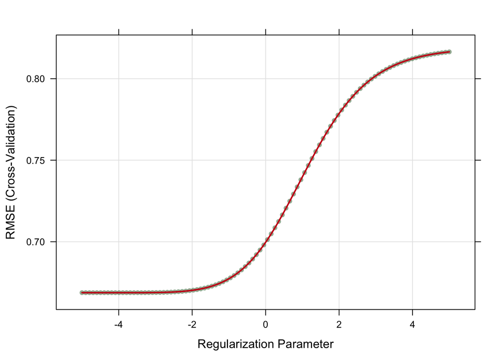

```r
#Ridge fit
set.seed(1)
ridge.fit <-train(x1, y1,method = "glmnet",
                  tuneGrid =expand.grid(alpha = 0,
                                        lambda =exp(seq(-5, 5, length=100))),
                  trControl = ctrl1)

plot(ridge.fit, xTrans =function(x)log(x))
```

```r
ridge.fit$bestTune
```

```
##    alpha     lambda
## 17     0 0.03391702
```

```r
coef(ridge.fit$finalModel,ridge.fit$bestTune$lambda)
```

```
## 12 x 1 sparse Matrix of class "dgCMatrix"
##                                  1
## (Intercept)           9.0114668597
## fixed_acidity         0.0009016876
## volatile_acidity     -1.0898151502
## citric_acid          -0.1422535882
## residual_sugar        0.0061130661
## chlorides            -2.0975893668
## free_sulfur_dioxide   0.0046283547
## total_sulfur_dioxide -0.0037296680
## density              -4.4319113330
## p_h                  -0.4225965078
## sulphates             0.9001022715
## alcohol               0.2607045994
```

```r
predict(ridge.fit, s = ridge.fit$bestTune, newdata = x2)
```

[output not shown]

[output cut: 45 more lines]

[output not shown]

```r
set.seed(1)
# Lasso
lasso.fit = train(x1, y1,method = "glmnet",
                  tuneGrid =expand.grid(alpha = 1,
                                        lambda =exp(seq(-10, 0, length=100))),
                  trControl = ctrl1)
summary(lasso.fit)
```

```
##             Length Class      Mode
## a0           77    -none-     numeric
## beta        847    dgCMatrix  S4
## df           77    -none-     numeric
## dim           2    -none-     numeric
## lambda       77    -none-     numeric
## dev.ratio    77    -none-     numeric
## nulldev       1    -none-     numeric
## npasses       1    -none-     numeric
## jerr          1    -none-     numeric
## offset        1    -none-     logical
## call          5    -none-     call
## nobs          1    -none-     numeric
## lambdaOpt     1    -none-     numeric
## xNames       11    -none-     character
## problemType   1    -none-     character
## tuneValue     2    data.frame list
## obsLevels     1    -none-     logical
## param         0    -none-     list
```

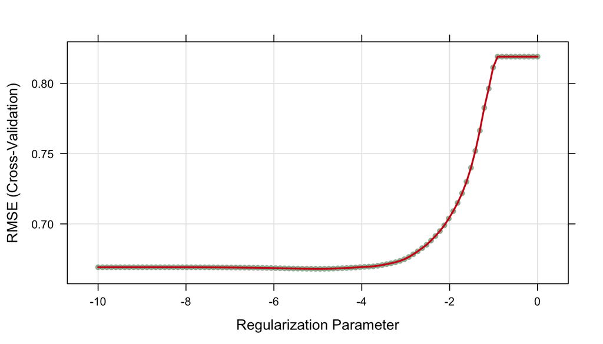

```r
plot(lasso.fit, xTrans =function(x)log(x))
```

```r
lasso.fit$bestTune
```

```
##    alpha      lambda
## 51     1 0.007086987
```

```r
coef(lasso.fit$finalModel,lasso.fit$bestTune$lambda)
```

```
## 12 x 1 sparse Matrix of class "dgCMatrix"
##                                 1
## (Intercept)           4.299374341
## fixed_acidity         .
## volatile_acidity     -1.094768881
## citric_acid          -0.100352537
## residual_sugar        .
## chlorides            -1.966318439
## free_sulfur_dioxide   0.003559132
## total_sulfur_dioxide -0.003357399
## density               .
## p_h                  -0.358346552
## sulphates             0.869445986
## alcohol               0.270717752
```

Treat the response quality as continous variable or classified variable How to treat quality as classified variable? factor the response

```r
#fit GAM  R^2 = 0.415
gam.fit <- train(x1, y1,
                 method = "gam",
                 tuneGrid = data.frame(method = "GCV.Cp", select = FALSE),
                 trControl = ctrl1)
summary(gam.fit)
```

```
##
## Family: gaussian
## Link function: identity
##
## Formula:
## .outcome ~ s(free_sulfur_dioxide) + s(alcohol) + s(citric_acid) +
##     s(residual_sugar) + s(p_h) + s(fixed_acidity) + s(sulphates) +
##     s(volatile_acidity) + s(chlorides) + s(total_sulfur_dioxide) +
##     s(density)
##
## Parametric coefficients:
##             Estimate Std. Error t value Pr(>|t|)
## (Intercept)   5.6342     0.0181   311.2   <2e-16 ***
## ---
## Signif. codes:  0 '***' 0.001 '**' 0.01 '*' 0.05 '.' 0.1 ' ' 1
##
## Approximate significance of smooth terms:
##                           edf Ref.df      F  p-value
## s(free_sulfur_dioxide)  2.543  3.253  2.301 0.074201 .
## s(alcohol)              3.472  4.361 16.911 4.96e-14 ***
## s(citric_acid)          3.037  3.832  1.371 0.261404
## s(residual_sugar)       6.622  7.700  1.142 0.325172
## s(p_h)                  1.000  1.000  9.941 0.001657 **
## s(fixed_acidity)        5.777  6.883  3.750 0.000685 ***
## s(sulphates)            3.739  4.648 23.298  < 2e-16 ***
## s(volatile_acidity)     2.247  2.910 16.978 1.40e-10 ***
## s(chlorides)            6.650  7.683  3.323 0.001635 **
## s(total_sulfur_dioxide) 7.371  8.230  4.851 4.95e-06 ***
## s(density)              1.614  2.043  0.568 0.566382
## ---
## Signif. codes:  0 '***' 0.001 '**' 0.01 '*' 0.05 '.' 0.1 ' ' 1
##
## R-sq.(adj) =  0.415   Deviance explained = 43.7%
## GCV = 0.40868  Scale est. = 0.39333   n = 1200
```

```r
gam.fit$finalModel
```

```
##
## Family: gaussian
## Link function: identity
##
## Formula:
## .outcome ~ s(free_sulfur_dioxide) + s(alcohol) + s(citric_acid) +
##     s(residual_sugar) + s(p_h) + s(fixed_acidity) + s(sulphates) +
##     s(volatile_acidity) + s(chlorides) + s(total_sulfur_dioxide) +
##     s(density)
##
## Estimated degrees of freedom:
## 2.54 3.47 3.04 6.62 1.00 5.78 3.74
## 2.25 6.65 7.37 1.61  total = 45.07
##
## GCV score: 0.40868
```

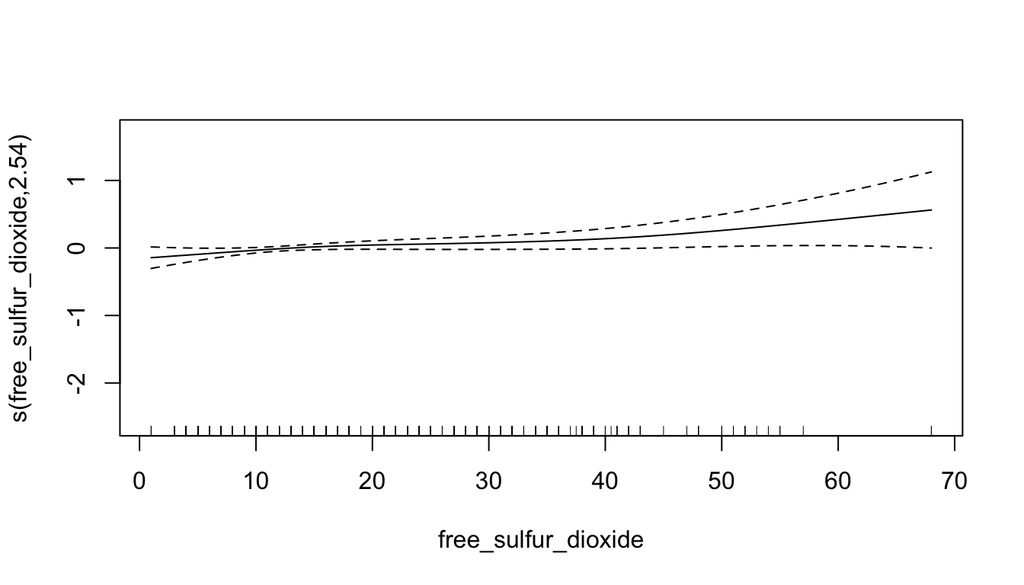

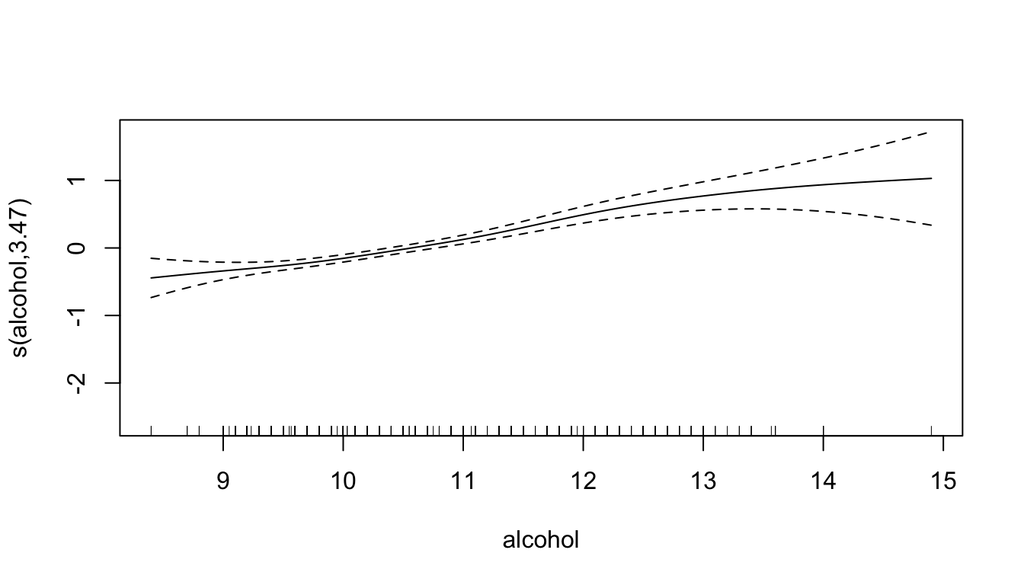

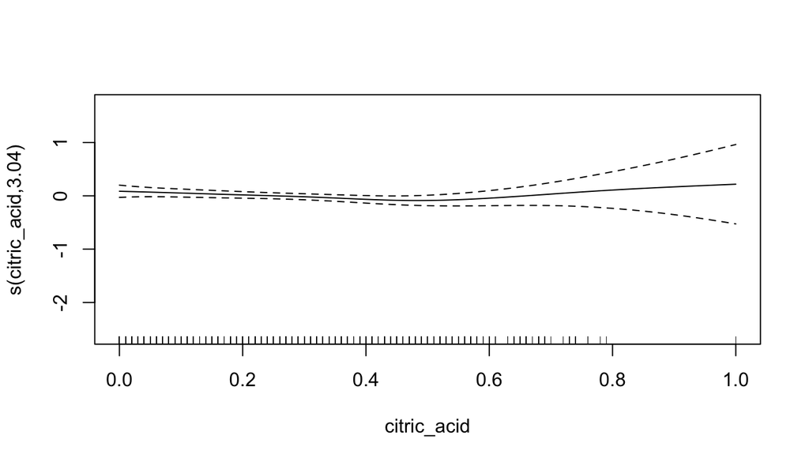

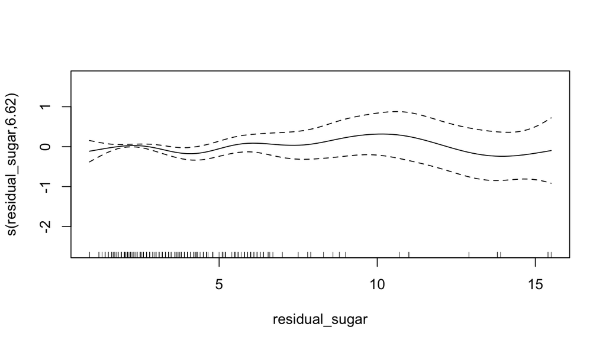

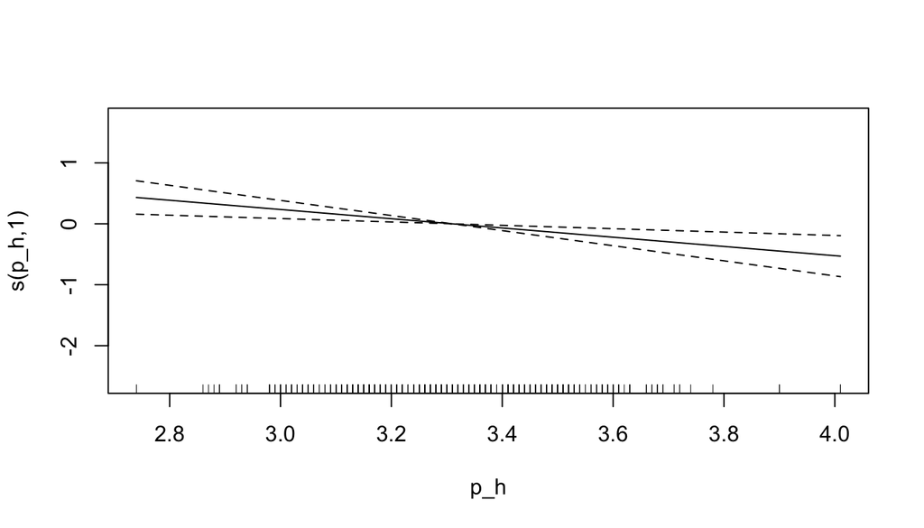

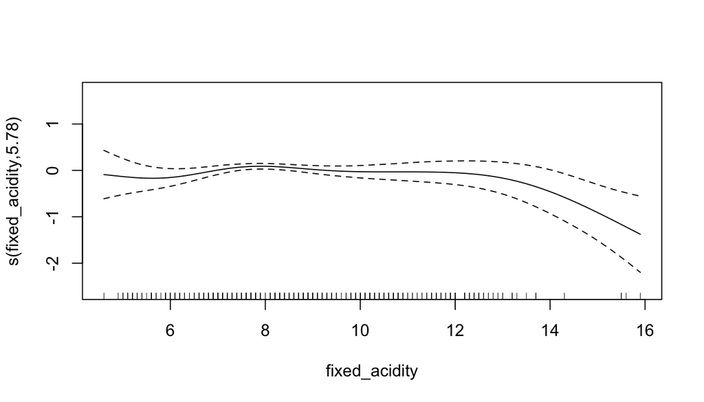

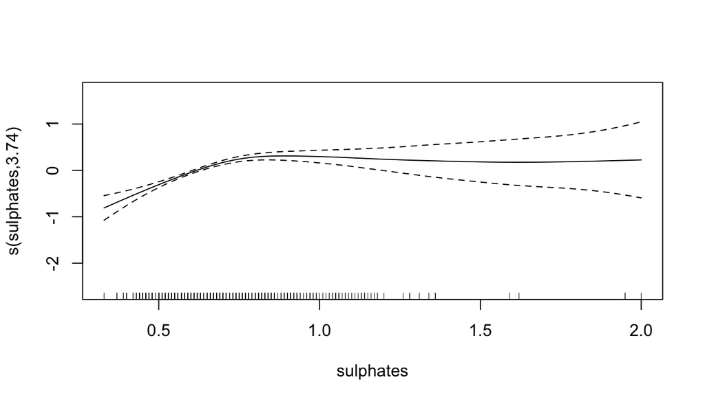

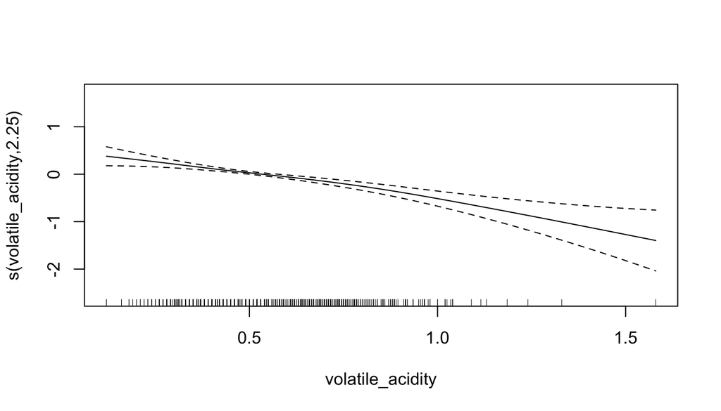

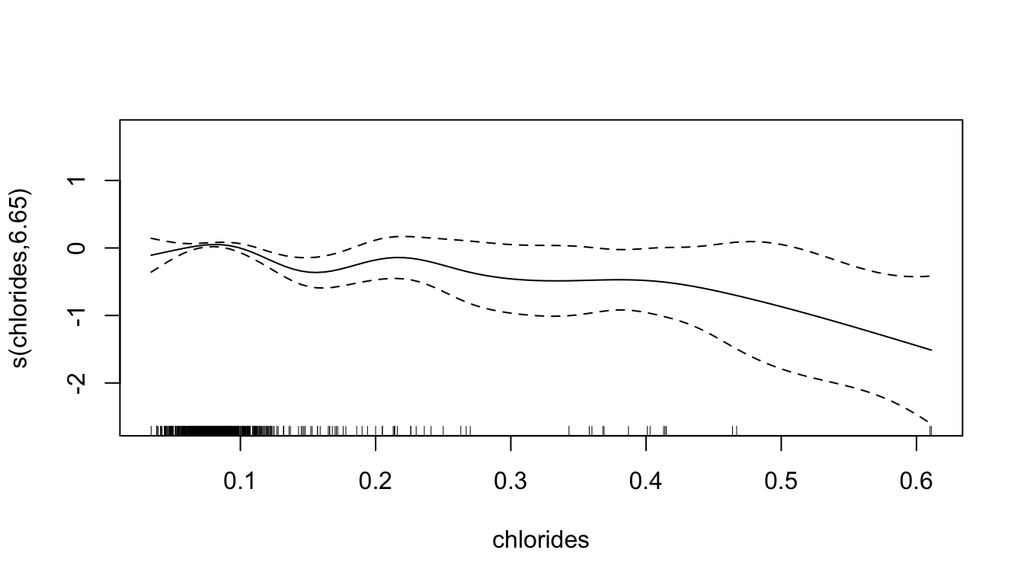

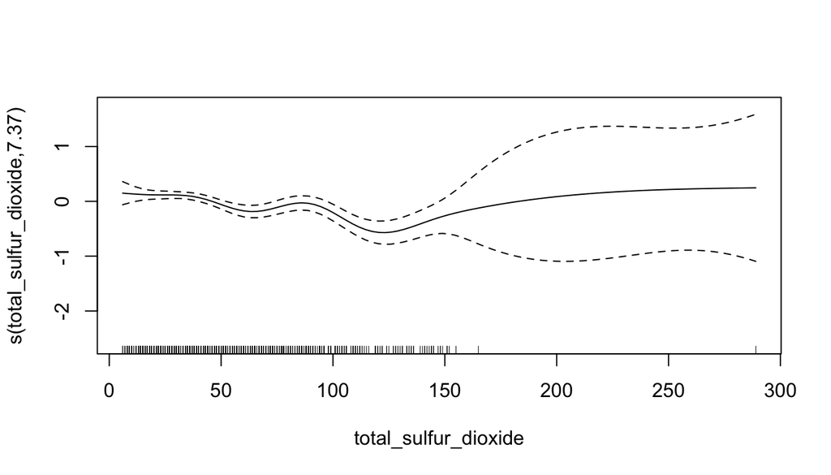

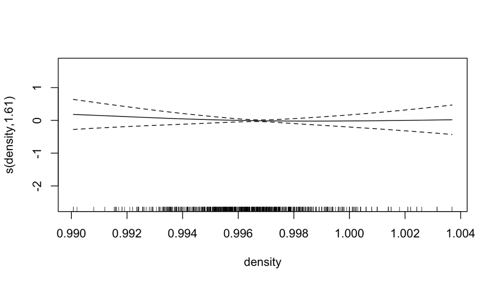

```r
plot(gam.fit$finalModel)
```

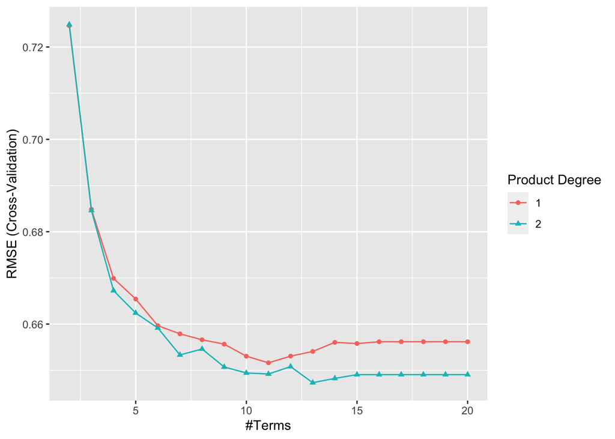

```r
# MARS R^2 = 0.4271106
mars_grid <- expand.grid(degree = 1:2,
                         nprune = 2:20)

set.seed(2)
mars.fit <- train(x1, y1,
                  method = "earth",
                  tuneGrid = mars_grid,
                  trControl = ctrl1)

ggplot(mars.fit)
```

```r
summary(mars.fit)
```

```
## Call: earth(x=matrix[1200,11], y=c(5,5,5,5,5,5,7...), keepxy=TRUE, degree=2,
##             nprune=13)
##
##                                                        coefficients
## (Intercept)                                                6.353930
## h(fixed_acidity-13)                                       -0.399714
## h(0.84-volatile_acidity)                                  -0.485023
## h(volatile_acidity-0.84)                                  -6.929117
## h(0.75-sulphates)                                         -1.999464
## h(12.4-alcohol)                                           -0.439408
## h(13-fixed_acidity) * h(0.99344-density)                  36.819312
## h(7.7-fixed_acidity) * h(0.75-sulphates)                  -1.206985
## h(fixed_acidity-7.7) * h(0.75-sulphates)                  -0.419182
## h(0.84-volatile_acidity) * h(127-total_sulfur_dioxide)     0.015733
## h(volatile_acidity-0.875) * h(12.4-alcohol)                2.939651
## h(13-free_sulfur_dioxide) * h(0.75-sulphates)             -0.148128
## h(0.98-sulphates) * h(12.4-alcohol)                        0.442814
##
## Selected 13 of 23 terms, and 7 of 11 predictors
## Termination condition: Reached nk 23
## Importance: alcohol, volatile_acidity, total_sulfur_dioxide, sulphates, ...
## Number of terms at each degree of interaction: 1 5 7
## GCV 0.4056702    RSS 461.9776    GRSq 0.3973292    RSq 0.4271106
```

```r
mars.fit$bestTune
```

```
##    nprune degree
## 31     13      2
```

```r
coef(mars.fit$finalModel)
```

```
##                                            (Intercept)
##                                             6.35393011
##                                        h(12.4-alcohol)
##                                            -0.43940823
##                               h(volatile_acidity-0.84)
##                                            -6.92911723
##                               h(0.84-volatile_acidity)
##                                            -0.48502320
##                                      h(0.75-sulphates)
##                                            -1.99946386
## h(0.84-volatile_acidity) * h(127-total_sulfur_dioxide)
##                                             0.01573317
##               h(fixed_acidity-7.7) * h(0.75-sulphates)
##                                            -0.41918174
##               h(7.7-fixed_acidity) * h(0.75-sulphates)
##                                            -1.20698484
##          h(13-free_sulfur_dioxide) * h(0.75-sulphates)
##                                            -0.14812773
##            h(volatile_acidity-0.875) * h(12.4-alcohol)
##                                             2.93965129
##                                    h(fixed_acidity-13)
##                                            -0.39971442
##                    h(0.98-sulphates) * h(12.4-alcohol)
##                                             0.44281428
##               h(13-fixed_acidity) * h(0.99344-density)
##                                            36.81931155
```

# Pick a model

Look R-squared

## Resample

```r
resamp = resamples(list(lm = lm.fit, ridge = ridge.fit, lasso = lasso.fit, mars = mars.fit, mars = mars.fit))

summary(resamp)
```

```
##
## Call:
## summary.resamples(object = resamp)
##
## Models: lm, ridge, lasso, mars, mars
## Number of resamples: 10
##
## MAE
##            Min.   1st Qu.    Median      Mean   3rd Qu.      Max. NA's
## mars  0.4461208 0.4640987 0.5179727 0.5058262 0.5436669 0.5537144    0
## lm    0.4756761 0.5032116 0.5141865 0.5164292 0.5337018 0.5484402    0
## ridge 0.4822950 0.5044316 0.5128260 0.5168221 0.5377467 0.5473404    0
## lasso 0.4818479 0.5048409 0.5129651 0.5162998 0.5373598 0.5486938    0
##
## RMSE
##            Min.   1st Qu.    Median      Mean   3rd Qu.      Max. NA's
## mars  0.5653679 0.5945104 0.6715856 0.6473109 0.6933566 0.7094372    0
## lm    0.6230933 0.6398692 0.6754646 0.6692341 0.6895602 0.7301717    0
## ridge 0.6280624 0.6402096 0.6732835 0.6687595 0.6890914 0.7311155    0
## lasso 0.6252294 0.6395429 0.6716251 0.6680095 0.6884275 0.7304541    0
##
## Rsquared
##            Min.   1st Qu.    Median      Mean   3rd Qu.      Max. NA's
## mars  0.2901899 0.3583227 0.3780700 0.3828875 0.4056280 0.5108525    0
## lm    0.2658004 0.2897558 0.3299586 0.3442508 0.3817542 0.4774045    0
## ridge 0.2685983 0.2924609 0.3257527 0.3447064 0.3830852 0.4736011    0
## lasso 0.2679148 0.2979226 0.3267503 0.3460655 0.3837787 0.4714428    0
```

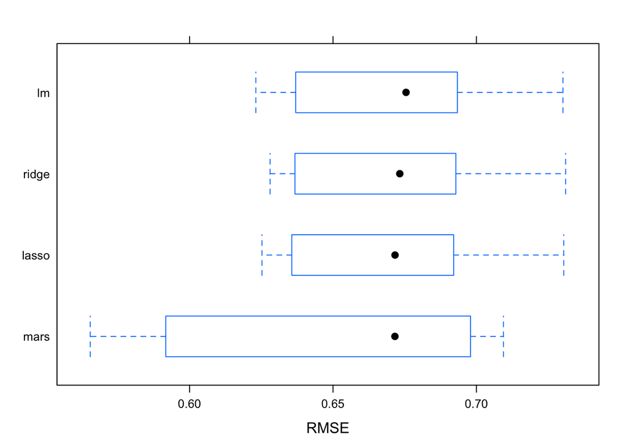

```r
bwplot(resamp, metric = "RMSE")
```